# DEP_EDU_DATA

Sam Shifflett,Danny Nguyen, Guang Yi Lim

4/17/2019

## SOURCES:

## __________________________

-DATA SOURCE

https://collegescorecard.ed.gov/data/

-SAM

https://www.tutorialspoint.com/r/r_functions.htm https://www.rdocumentation.org/packages/stringr/versions/1.4.0/topics/str_detect https://stackoverflow.com/questions/17499013/how-do-i-make-a-list-of-data-frames https://www.rdocumentation.org/packages/base/versions/3.5.3/topics/paste

row names to column https://stackoverflow.com/questions/29511215/convert-row-names-into-first-column

transpose dataframe http://www.rpubs.com/Mentors_Ubiqum/Transpose_Dataframe

Knitting options https://kbroman.org/knitr_knutshell/pages/Rmarkdown.html

-LIM

https://stackoverflow.com/questions/43456687/using-dplyr-gsub-on-many-columns https://cran.r-project.org/web/packages/cowplot/vignettes/introduction.html https://stackoverflow.com/questions/12297859/remove-all-text-before-colon https://stackoverflow.com/questions/47054901/merge-and-sum-two-different-data-tables https://stackoverflow.com/questions/28775036/ggplot-line-graph-with-na-values

-DANNY

https://stackoverflow.com/questions/10357768/plotting-lines-and-the-group-aesthetic-in-ggplot2 https://stackoverflow.com/questions/3777174/plotting-two-variables-as-lines-using-ggplot2-on-the-same-graph https://stackoverflow.com/questions/32588215/add-multiple-geom-line-to-ggplot?rq=1 https://stackoverflow.com/questions/34379268/ggplot-and-two-different-geom-line-the-legend-does-not-appear/34379376 -

## ___________________________

## PREPARE THE DATA

```r
library(httr)
library(ggplot2)
library(jsonlite)
library(tidyverse)
library(plyr)
library(data.table)
library(cowplot)
options(scipen = 999)
#This is the URL for ISU data
url = "https://api.data.gov/ed/collegescorecard/v1/schools.json?api_key=KYthZktaAwB5CMGp9Keyl3raXpb6CS43CaMhbLkr&school.name=Iowa%20State%20University"
#This is the URL for UniIowa data
UIowaURL = "https://api.data.gov/ed/collegescorecard/v1/schools.json?api_key=KYthZktaAwB5CMGp9Keyl3raXpb6CS43CaMhbLkr&school.name=University%20of%20Iowa"
data_get<- GET(url)
data_get2 <- GET(UIowaURL)
get2json<- content(data_get, as = "parsed")
get2json2 <- content(data_get2, as = "parsed")
#----------------------------
#This function parses the Json repsonse into a dataframe for each category that we are analyzing
get_subs <- function(name) {
  completion = unlist(fromJSON(toJSON(name$completion,flatten=TRUE)))
  students = unlist(fromJSON(toJSON(name$student,flatten=TRUE)))
  admissions = unlist(fromJSON(toJSON(name$admissions,flatten=TRUE)))
  academics = unlist(fromJSON(toJSON(name$academics,flatten=TRUE)))
  aid = unlist(fromJSON(toJSON(name$aid,flatten=TRUE)))
  repayment = unlist(fromJSON(toJSON(name$repayment,flatten=TRUE)))
  earnings = unlist(fromJSON(toJSON(name$earnings,flatten=TRUE)))
  cost = unlist(fromJSON(toJSON(name$cost,flatten=TRUE)))
  completion = data.frame(completion)
  students = data.frame(students)
  admissions = data.frame(admissions)
  academics = data.frame(academics)
  aid = data.frame(aid)
  repayment= data.frame(repayment)
  earnings= data.frame(earnings)
  cost= data.frame(cost)
  yearList = c(list(completion),list(students),list(admissions),list(academics),list(aid),list(repayment),list(earnings),list(cost))
  add_col_name(yearList)
  return(change_zeros(yearList))
}

#creates a column in the first column for selecting
add_col_name <- function(data) {
  for(i in seq(from=1,to=length(data))) {
    if(dim(data[[i]]) != 0) {
      setDT(data[[i]], keep.rownames = TRUE)[]
    }
  }
}

#creates a new dataframe for dataframes with no repsonse from get_subs
change_zeros <- function(collect) {
  datalist = c()
  for(i in seq(from=1,to=length(collect),by=1)) {
    if(ncol(collect[[i]]) == 0) {
      data = data.frame(rn=c("avg_net_price.overall","students_with_pell_grant","sat_scores.average.overall","program_percentage.education","pell_grant_rate","repayment_cohort.3_year_declining_balance","6_yrs_after_entry.working_not_enrolled.income.lowest_tercile","avg_net_price.public"),empty="None")
      datalist = c(datalist,list(data))
    }
    else {
      datalist = c(datalist,list(collect[[i]]))
    }
  }
  return(datalist)
}

#grabs the ISU data associated with a certain subtopic and puts them into a list for each year
ISUlist_topics <- function(number) {
  tempList = list(ISUdata1997[[number]],ISUdata1998[[number]],ISUdata1999[[number]],ISUdata2000[[number]],ISUdata2001[[number]],ISUdata2002[[number]],ISUdata2003[[number]],ISUdata2004[[number]],ISUdata2005[[number]],ISUdata2006[[number]],ISUdata2007[[number]],ISUdata2008[[number]],ISUdata2009[[number]],ISUdata2010[[number]],ISUdata2011[[number]],ISUdata2012[[number]])
  return(rev(tempList))
}

#grabs the UI data associated with a certain subtopic and puts them into a list for each year
UIlist_topics <- function(number) {
  tempList = list(UIdata1997[[number]],UIdata1998[[number]],UIdata1999[[number]],UIdata2000[[number]],UIdata2001[[number]],UIdata2002[[number]],UIdata2003[[number]],UIdata2004[[number]],UIdata2005[[number]],UIdata2006[[number]],UIdata2007[[number]],UIdata2008[[number]],UIdata2009[[number]],UIdata2010[[number]],UIdata2011[[number]],UIdata2012[[number]])
  return(rev(tempList))
}

#joins all of the dataframes for each subtopic for ISU data
ISUjoin_rename <- function(number) {
  namesData = c("1997","1998","1999","2000","2001","2002","2003","2004","2005","2006","2007","2008","2009","2010","2011","2012","stat")
  data = join_all(ISUlist_topics(number), by='rn', type='left')
  names(data) = rev(namesData)
  t_data = as.data.frame(t(as.matrix(data)))
  DF = t_data[2:nrow(t_data),1:ncol(t_data)]
  colnames(DF) = data[,1]
  for(i in seq(from=1,to=ncol(DF),by=1)) {
    names(DF)[i] = data[,1][i]
  }
  setDT(DF, keep.rownames = TRUE)[]
  return(DF)
}

#joins all of the dataframes for each subtopic for UI data
UIjoin_rename <- function(number) {
  namesData = c("1997","1998","1999","2000","2001","2002","2003","2004","2005","2006","2007","2008","2009","2010","2011","2012","stat")
  data = join_all(UIlist_topics(number), by='rn', type='left')
  names(data) = rev(namesData)
  t_data = as.data.frame(t(as.matrix(data)))
  DF = t_data[2:nrow(t_data),1:ncol(t_data)]
  colnames(DF) = data[,1]
  for(i in seq(from=1,to=ncol(DF),by=1)) {
    names(DF)[i] = data[,1][i]
  }
  setDT(DF, keep.rownames = TRUE)[]
  return(DF)
}

#create dataframes for each sub category for each year
ISUdata2012 = get_subs(get2json$results[[1]]$`2012`)
ISUdata2011 = get_subs(get2json$results[[1]]$`2011`)
ISUdata2010 = get_subs(get2json$results[[1]]$`2010`)
ISUdata2009 = get_subs(get2json$results[[1]]$`2009`)
ISUdata2008 = get_subs(get2json$results[[1]]$`2008`)
ISUdata2007 = get_subs(get2json$results[[1]]$`2007`)
ISUdata2006 = get_subs(get2json$results[[1]]$`2006`)
ISUdata2005 = get_subs(get2json$results[[1]]$`2005`)
ISUdata2004 = get_subs(get2json$results[[1]]$`2004`)
ISUdata2003 = get_subs(get2json$results[[1]]$`2003`)
ISUdata2002 = get_subs(get2json$results[[1]]$`2002`)
ISUdata2001 = get_subs(get2json$results[[1]]$`2001`)
ISUdata2000 = get_subs(get2json$results[[1]]$`2000`)
ISUdata1999 = get_subs(get2json$results[[1]]$`1999`)
ISUdata1998 = get_subs(get2json$results[[1]]$`1998`)
ISUdata1997 = get_subs(get2json$results[[1]]$`1997`)
ISUdata1996 = get_subs(get2json$results[[1]]$`1996`)
#join all of the dataframes from each year into one full dataframe by subtopic
ISUcompletionData = ISUjoin_rename(1)
ISUstudentsData = ISUjoin_rename(2)
ISUadmissionData = ISUjoin_rename(3)
ISUacademicsData = ISUjoin_rename(4)
ISUaidData = ISUjoin_rename(5)
ISUrepaymentData = ISUjoin_rename(6)
ISUearningsData = ISUjoin_rename(7)
ISUcostData <- ISUjoin_rename(8)

#create dataframes for each sub category for each year
UIdata2012 = get_subs(get2json2$results[[1]]$`2012`)
UIdata2011 = get_subs(get2json2$results[[1]]$`2011`)
UIdata2010 = get_subs(get2json2$results[[1]]$`2010`)
UIdata2009 = get_subs(get2json2$results[[1]]$`2009`)
UIdata2008 = get_subs(get2json2$results[[1]]$`2008`)
UIdata2007 = get_subs(get2json2$results[[1]]$`2007`)
UIdata2006 = get_subs(get2json2$results[[1]]$`2006`)
UIdata2005 = get_subs(get2json2$results[[1]]$`2005`)
UIdata2004 = get_subs(get2json2$results[[1]]$`2004`)
UIdata2003 = get_subs(get2json2$results[[1]]$`2003`)
UIdata2002 = get_subs(get2json2$results[[1]]$`2002`)
UIdata2001 = get_subs(get2json2$results[[1]]$`2001`)
UIdata2000 = get_subs(get2json2$results[[1]]$`2000`)
UIdata1999 = get_subs(get2json2$results[[1]]$`1999`)
UIdata1998 = get_subs(get2json2$results[[1]]$`1998`)
UIdata1997 = get_subs(get2json2$results[[1]]$`1997`)
UIdata1996 = get_subs(get2json2$results[[1]]$`1996`)
#join all of the dataframes from each year into one full dataframe by subtopic
UIcompletionData = UIjoin_rename(1)
UIstudentsData = UIjoin_rename(2)
UIadmissionData = UIjoin_rename(3)
UIacademicsData = UIjoin_rename(4)
UIaidData = UIjoin_rename(5)
UIrepaymentData = UIjoin_rename(6)
UIearningsData = UIjoin_rename(7)
UIcostData = UIjoin_rename(8)
```

### ——–DANNY———

# 4 Year Completion Cohorts

This graph displays the data of ISU and UofIowa students that completed school in 4 years. The y-axis displays the count of students and the x-axis displays the year. The top 2 lines of the plot show the total count of both female and male students for both universities. The bottom 4 lines show the count of both genders separately along with indicated color of the university which can be seen on the legend that is on the right side of the plot. The plot itself was designed to compare the number of students that completed their education in 4 years from both universities. For all five of my visualizations I made an inner join of both universities’ specified data frames. I then selected the specific variables to be used in each respective plot and fill the correct plotting parameters.

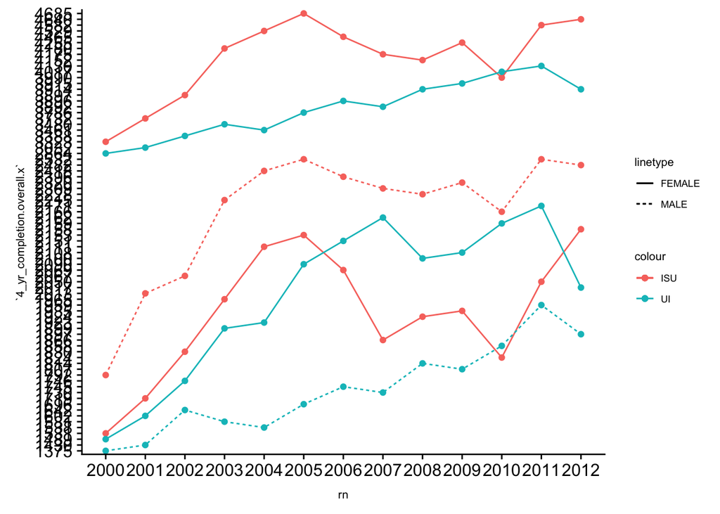

```r
#comparison between the count of ISU and UI 4 year completion students.
ISUvsUIcompl = inner_join(ISUcompletionData, UIcompletionData, by = "rn")
ISUvsUIcompl = ISUvsUIcompl %>% select(rn, `4_yr_completion.overall.x`, `4_yr_completion.female_students.x`, `4_yr_completion.male_students.x`, `4_yr_completion.overall.y`, `4_yr_completion.female_students.y`, `4_yr_completion.male_students.y`)
ISUvsUIcompl = ISUvsUIcompl[complete.cases(ISUvsUIcompl), ]
ggplot(ISUvsUIcompl) +
  geom_line(aes(x = rn, y = `4_yr_completion.overall.x`, group = 1, color = "ISU")) +
  geom_line(aes(x = rn, y = `4_yr_completion.overall.y`, group = 1, color = "UI")) +
  geom_line(aes(x = rn, y = `4_yr_completion.female_students.x`, group = 1, color = "ISU", linetype = "FEMALE")) +
  geom_line(aes(x = rn, y = `4_yr_completion.male_students.x`, group = 1, color = "ISU", linetype = "MALE")) +
  geom_line(aes(x = rn, y = `4_yr_completion.female_students.y`, group = 1, color = "UI", linetype = "FEMALE")) +
  geom_line(aes(x = rn, y = `4_yr_completion.male_students.y`, group = 1, color = "UI", linetype = "MALE")) +
  geom_point(aes(x = rn, y = `4_yr_completion.overall.x`, group = 1, color = "ISU")) +
  geom_point(aes(x = rn, y = `4_yr_completion.overall.y`, group = 1, color = "UI")) +
  geom_point(aes(x = rn, y = `4_yr_completion.female_students.x`, group = 1, color = "ISU", linetype = "FEMALE")) +
  geom_point(aes(x = rn, y = `4_yr_completion.male_students.x`, group = 1, color = "ISU", linetype = "MALE")) +
  geom_point(aes(x = rn, y = `4_yr_completion.female_students.y`, group = 1, color = "UI", linetype = "FEMALE")) +
  geom_point(aes(x = rn, y = `4_yr_completion.male_students.y`, group = 1, color = "UI", linetype = "MALE")) + theme(text = element_text(size=8))
```

# Average Overall SAT Scores

This plot displays the data of average overall SAT scores from both ISU and UofIowa. The y-axis displays the sat score range while the x-axis displays the year. The plotted lines show the trend of data from both universities with indicated colors that can be seen on the legend located on the right side of the plot. The plot itself was designed to compare the average overall SAT scores between both universities.

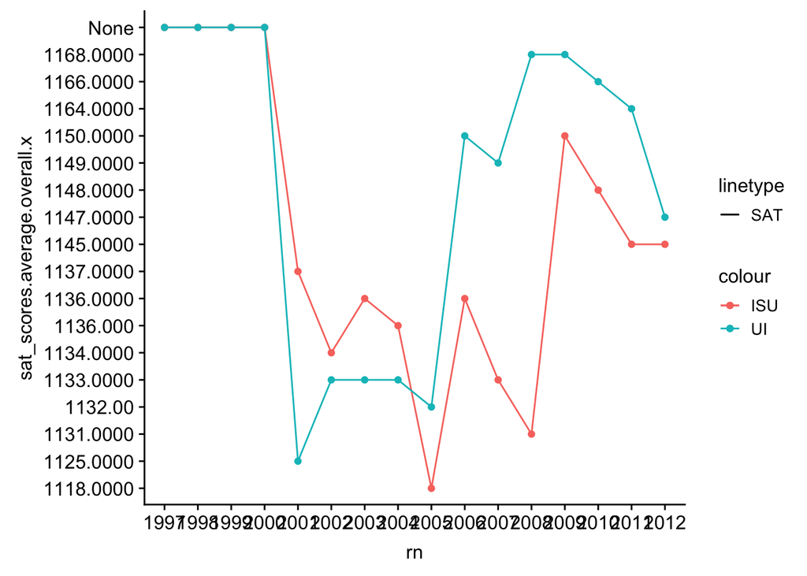

```r
#comparison of average overall sat scores between ISU and UI.
ISUvsUIadmis = inner_join(ISUadmissionData, UIadmissionData, by = "rn")
ISUvsUIadmis = ISUvsUIadmis %>% select(rn, `sat_scores.average.overall.x`, `sat_scores.average.overall.y`)
ISUvsUIadmis = ISUvsUIadmis[complete.cases(ISUvsUIadmis), ]
ggplot(ISUvsUIadmis) +
  geom_line(aes(x = rn, y = `sat_scores.average.overall.x`, group = 1, color = "ISU", linetype = "SAT")) +
  geom_line(aes(x = rn, y = `sat_scores.average.overall.y`, group = 1, color = "UI", linetype = "SAT")) +
  geom_point(aes(x = rn, y = `sat_scores.average.overall.x`, group = 1, color = "ISU", linetype = "SAT")) +
  geom_point(aes(x = rn, y = `sat_scores.average.overall.y`, group = 1, color = "UI", linetype = "SAT"))  + theme(text = element_text(size=12))
```

# Overall Admission Rates

This plot displays data of the overall admission rates from both ISU and UofIowa. The y-axis displays the percentage range of the overall admission rates while the x-axis displays the year. The plotted lines show the trend of data from both universities with indicated colors that can be seen on the legend located on the right side of the plot. This plot was designed to compare the overall admission rates of both universities.

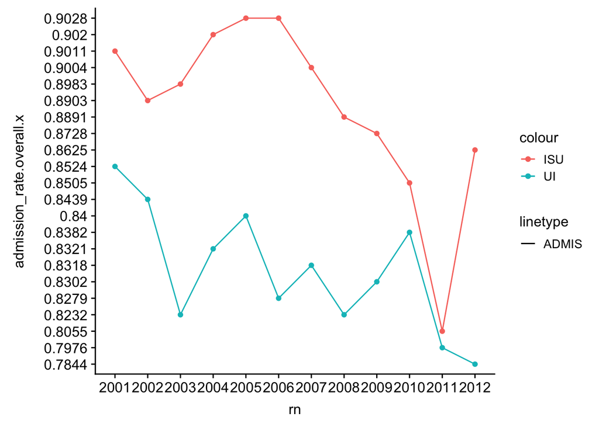

```r
#comparison of overall admission rates between ISU and UI.
ISUvsUIadmis2 = inner_join(ISUadmissionData, UIadmissionData, by = "rn")
ISUvsUIadmis2 = ISUvsUIadmis2 %>% select(rn, `admission_rate.overall.x`, `admission_rate.overall.y`)
ISUvsUIadmis2 = ISUvsUIadmis2[complete.cases(ISUvsUIadmis2), ]
ggplot(ISUvsUIadmis2) +
  geom_line(aes(x = rn, y = `admission_rate.overall.x`, group = 1, color = "ISU", linetype = "ADMIS")) +
  geom_line(aes(x = rn, y = `admission_rate.overall.y`, group = 1, color = "UI", linetype = "ADMIS")) +
  geom_point(aes(x = rn, y = `admission_rate.overall.x`, group = 1, color = "ISU", linetype = "ADMIS")) +
  geom_point(aes(x = rn, y = `admission_rate.overall.y`, group = 1, color = "UI", linetype = "ADMIS")) + theme(text = element_text(size=12))
```

# Contribution:

### ——–DANNY———

### ———LIM———-

# Top 10 program with highest student percentage

This chart shows the top 10 programs with the highest number of students. I summarized the dataframe to give us a mean student percentage over the years for each school. I made seperate bar charts for each school and then use cowplot to combine both barcharts into one graph. Surprisingly, both school had buissness marketing as the program. One thing to note is that ISU seems to be more focused on certain areas, with buisness marketing and engineering making up more than 30% of the schools students.

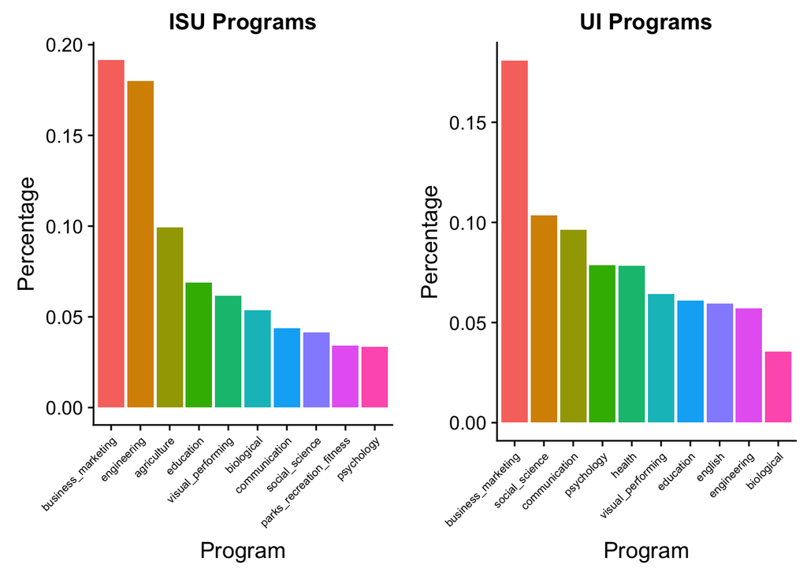

```r
temp1 <- ISUacademicsData %>% select(1:39)
temp1 <- type.convert(temp1)
maybe <-temp1 %>% summarise_at(c(2:39),mean)
maybe1 <- as.data.frame(t(maybe))
d <- cbind(rownames(maybe1),data.frame(maybe1,row.names = NULL))
colnames(d) <- c("Program","ISUPercentage")
d$Program <- as.character(d$Program)
d<- d %>% mutate(Program = gsub("program_percentage.","",Program))
d$Program <- as.factor(d$Program)
d$Program <- reorder(d$Program,-d$ISUPercentage)



temp2 <- UIacademicsData %>% select(1:39)
temp2 <- type.convert(temp2)
maybe <-temp2 %>% summarise_at(c(2:39),mean)
maybe1 <- as.data.frame(t(maybe))
c <- cbind(rownames(maybe1),data.frame(maybe1,row.names = NULL))
colnames(c) <- c("Program","UIPercentage")
c$Program <- as.character(c$Program)
c<- c %>% mutate(Program = gsub("program_percentage.","",Program))
c$Program <- as.factor(c$Program)
c$Program <- reorder(c$Program,-c$UIPercentage)

#plot of highes intake for programs between unis
d<- d %>% arrange(desc(ISUPercentage))
c<- c %>% arrange(desc(UIPercentage))
ISU <-ggplot(head(d,10),aes(x= Program,y= ISUPercentage,fill = Program))+geom_col() + theme(legend.position = "none")+
  ylab("Percentage")+ggtitle("ISU Programs")+theme(axis.text.x = element_text(angle = 45, size =7,hjust = 1))
UI <-ggplot(head(c,10),aes(x= Program,y= UIPercentage,fill = Program))+geom_col() + theme(legend.position = "none")+
  ylab("Percentage")+ggtitle("UI Programs")+theme(axis.text.x = element_text(angle = 45,size = 7,hjust =1))
plot_grid(ISU,UI,labels = c("",""))
```

# Students family income level

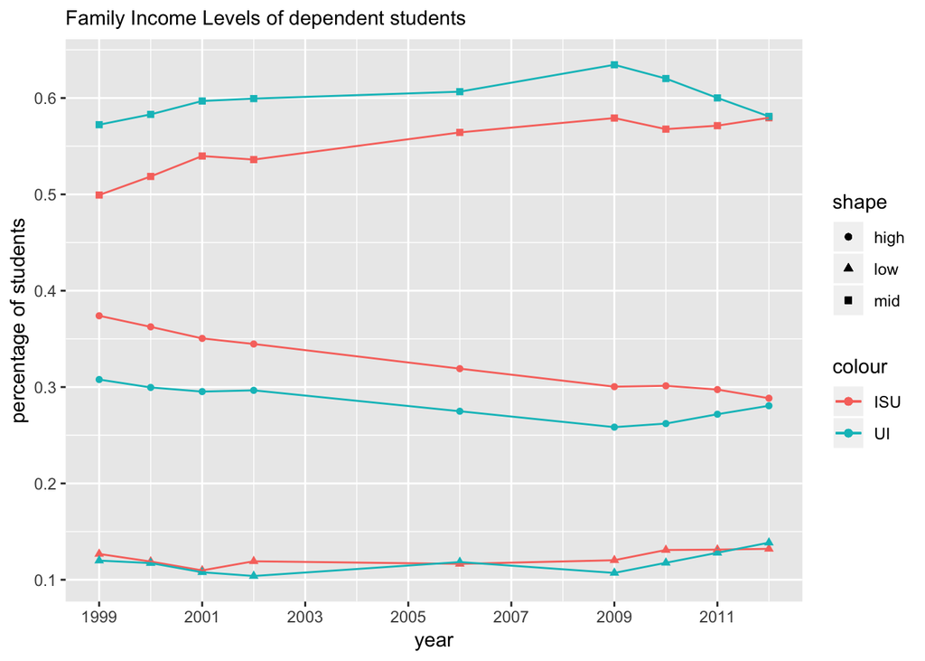

```r
temp1 <- ISUstudentsData[,c(1,6,11,12,40,41)]
temp2 <- UIstudentsData[,c(1,6,11,12,40,41)]
ISUvsUIfamilyIncome <- inner_join(temp1,temp2,by = "rn")
ISUvsUIfamilyIncome <- type.convert(ISUvsUIfamilyIncome)
colnames(ISUvsUIfamilyIncome) <-c("year","ISU low Income","ISU 30,000","ISU 48,000","ISU 75,000","ISU 110,000","UI low Income","UI 30,000","UI 48,000","UI 75,000","UI 110,000")
ISUvsUIfamilyIncome <- ISUvsUIfamilyIncome %>% mutate('ISU middle Income' = `ISU 30,000`+`ISU 48,000`,'ISU high Income' = `ISU 75,000`+`ISU 110,000`,
                                                      'UI middle Income' = `UI 30,000`+`UI 48,000`,'UI high Income' = `UI 75,000`+`UI 110,000`)
ISUvsUIfamilyIncome <- ISUvsUIfamilyIncome[,c(1,2,7,12:15)]
t <- na.omit(ISUvsUIfamilyIncome)
#change the value of the x axis to skip the missing data
ggplot(t,aes(x=year))+
  geom_point(aes(y=`ISU low Income`,group=1,color="ISU",shape = "low"))+
  geom_point(aes(y=`ISU middle Income`,group=1,color="ISU",shape = "mid"))+
  geom_point(aes(y=`ISU high Income`,group=1,color="ISU",shape = "high"))+
  geom_point(aes(y=`UI low Income`,group=1,color="UI",shape = "low"))+
  geom_point(aes(y=`UI middle Income`,group=1,color="UI",shape ="mid"))+
  geom_point(aes(y=`UI high Income`,group=1,color="UI",shape = "high"))+
  geom_line(aes(y=`ISU low Income`,group=1,color="ISU",))+
  geom_line(aes(y=`ISU middle Income`,group=1,color="ISU"))+
  geom_line(aes(y=`ISU high Income`,group=1,color="ISU"))+
  geom_line(aes(y=`UI low Income`,group=1,color="UI"))+
  geom_line(aes(y=`UI middle Income`,group=1,color="UI"))+
  geom_line(aes(y=`UI high Income`,group=1,color="UI"))+
  ylab("percentage of students")+
  scale_x_continuous(breaks = seq(1999,2012,by = 2))+
  scale_y_continuous(breaks= seq(0, max(t$`UI middle Income`),0.1))+
  theme_grey()+ggtitle("Family Income Levels of dependent students")+
  theme(plot.title = element_text(size = 11))
```

# Number of students over the years.

This graph shows the number of students for schools over time. I subsetted the data to show dependet and independent students. The number of independet students were low for both schools, however it has been increasing slowly for UI. ISU has a larger numbe of dependent students when compared to UI, even when the numbers fell during 2002 the school still had more students than UI.

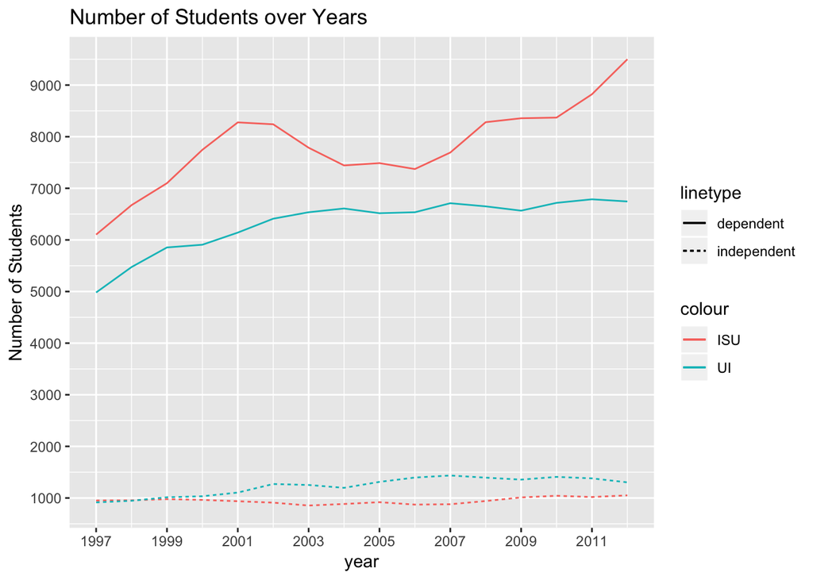

```r
temp1 <- ISUstudentsData[,c(1,7,9)]
temp2 <- UIstudentsData[,c(1,7,9)]
temp3 <- inner_join(temp1,temp2,by= "rn")
temp3 <- type.convert(temp3)
colnames(temp3) <- c("year","family independent ISU","family dependent ISU","family independent UI","family dependent UI")
ggplot(temp3,aes(x = year))+
  geom_line(aes(y= `family independent ISU`,group = 1,color = "ISU", linetype = "independent"))+
  geom_line(aes(y= `family dependent ISU`,group = 1,color = "ISU", linetype = "dependent"))+
  geom_line(aes(y= `family independent UI`,group = 1,color = "UI", linetype = "independent"))+
  geom_line(aes(y= `family dependent UI`,group = 1,color = "UI", linetype = "dependent"))+
  ylab("Number of Students")+
  scale_y_continuous(breaks = seq(0, max(temp3$`family dependent ISU`),1000))+
  scale_x_continuous(breaks = seq(1997,2012,by = 2))+
  theme(axis.text = element_text(size = 8),axis.title = element_text(size = 10))+
  theme_grey()+
  ggtitle("Number of Students over Years")
```

# Contribution

### ———LIM———-

### ———SAM———–

# Mean Earnings 10 Years After Entry

This graph shows the mean earnings of individuals 10 years after their entry to their college. I subsetted the list by male and female and also placed the mean earnings for the school itself. As you can see, Males earn a substanial larger amount than females according to this graph. Males also earn much more than the average of both schools. Another important point is that the mean earnings for ISU is about $4000 less than Univeristy of Iowa. This graph may say a good amount, but there are many other factors that tie into the assumptions made from this graph.

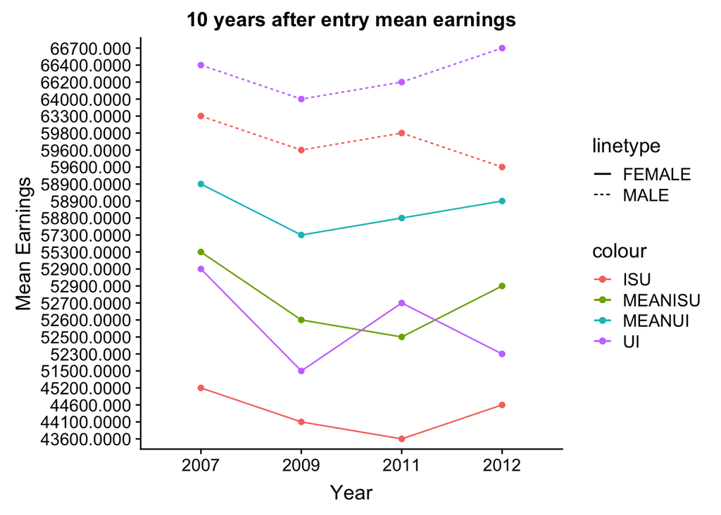

```r
ISUvsUIearnings = inner_join(ISUearningsData,UIearningsData,by="rn")
ISUvsUIearnings = ISUvsUIearnings %>% select(rn,`10_yrs_after_entry.working_not_enrolled.mean_earnings.x`,`10_yrs_after_entry.mean_earnings.female_students.x`,`10_yrs_after_entry.mean_earnings.male_students.x`,`10_yrs_after_entry.working_not_enrolled.mean_earnings.y`,`10_yrs_after_entry.mean_earnings.female_students.y`,`10_yrs_after_entry.mean_earnings.male_students.y`)
ISUvsUIearnings = ISUvsUIearnings[complete.cases(ISUvsUIearnings), ]
ggplot(ISUvsUIearnings) +
geom_line(aes(x=rn,y=`10_yrs_after_entry.working_not_enrolled.mean_earnings.x`,group = 1,color="MEANISU")) +
geom_line(aes(x=rn,y=`10_yrs_after_entry.working_not_enrolled.mean_earnings.y`,group = 1,color="MEANUI")) +
geom_line(aes(x=rn,y=`10_yrs_after_entry.mean_earnings.female_students.x`,group = 1,color="ISU",linetype="FEMALE")) +
geom_line(aes(x=rn,y=`10_yrs_after_entry.mean_earnings.male_students.x`,group = 1,color="ISU",linetype="MALE")) +
geom_line(aes(x=rn,y=`10_yrs_after_entry.mean_earnings.female_students.y`,group = 1,color="UI",linetype="FEMALE")) +
geom_line(aes(x=rn,y=`10_yrs_after_entry.mean_earnings.male_students.y`,group = 1,color="UI",linetype="MALE")) +
geom_point(aes(x=rn,y=`10_yrs_after_entry.working_not_enrolled.mean_earnings.x`,group = 1,color="MEANISU")) +
geom_point(aes(x=rn,y=`10_yrs_after_entry.working_not_enrolled.mean_earnings.y`,group = 1,color="MEANUI")) +
geom_point(aes(x=rn,y=`10_yrs_after_entry.mean_earnings.female_students.x`,group = 1,color="ISU",linetype="FEMALE")) +
geom_point(aes(x=rn,y=`10_yrs_after_entry.mean_earnings.male_students.x`,group = 1,color="ISU",linetype="MALE")) +
geom_point(aes(x=rn,y=`10_yrs_after_entry.mean_earnings.female_students.y`,group = 1,color="UI",linetype="FEMALE")) +
geom_point(aes(x=rn,y=`10_yrs_after_entry.mean_earnings.male_students.y`,group = 1,color="UI",linetype="MALE"))+ ylab("Mean Earnings") + xlab("Year") + ggtitle("10 years after entry mean earnings")
```

# Median Debt for Completers and Non-Completers

This graph displays the median debt values by year for Completers and Non-Completers. The graph shows that Completers have much more debt as compared to their counterparts. This is expected because Non-Completers obviously do not have to pay for all 4 years of a Bachelor’s. There is an unepected spike in debt though beginning in 2008. This may be because of the economic disaster during that time.

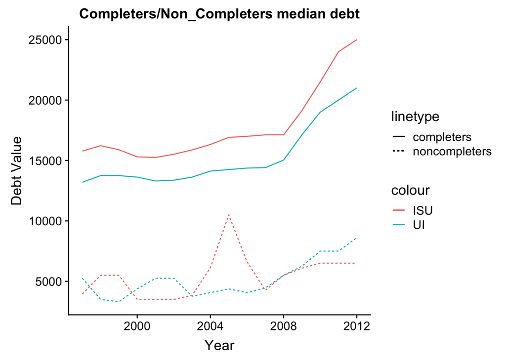

```r
data1 = ISUaidData %>% select(rn,median_debt.completers.overall,median_debt.noncompleters)
data2 = UIaidData %>% select(rn,median_debt.completers.overall,median_debt.noncompleters)
ISUvsUIcompleters = inner_join(data1,data2,by='rn')
ISUvsUIcompleters = type.convert(ISUvsUIcompleters)
ggplot(ISUvsUIcompleters,aes(x=rn))+
geom_line(aes(y=median_debt.completers.overall.x,group=1,color="ISU",linetype="completers"))+
geom_line(aes(y=median_debt.completers.overall.y,group=1,color="UI",linetype="completers"))+
geom_line(aes(y=median_debt.noncompleters.x,group=1,color="ISU",linetype="noncompleters"))+
geom_line(aes(y=median_debt.noncompleters.y,group=1,color="UI",linetype="noncompleters"))+
  xlab("Year")+ylab("Debt Value")+ggtitle("Completers/Non_Completers median debt")
```

# Two Year Default Rates by Tuition

This graph displays the two year default rates by the amount that tuition is. I have split the points into In-State and Out-of-State respectively. There is a strange sweet spot in each section that makes the two year default rates decrease. The lower or higher tuition is, the higher the default rate. But, right in the middle of the tuition range is where the default rate is lowest.

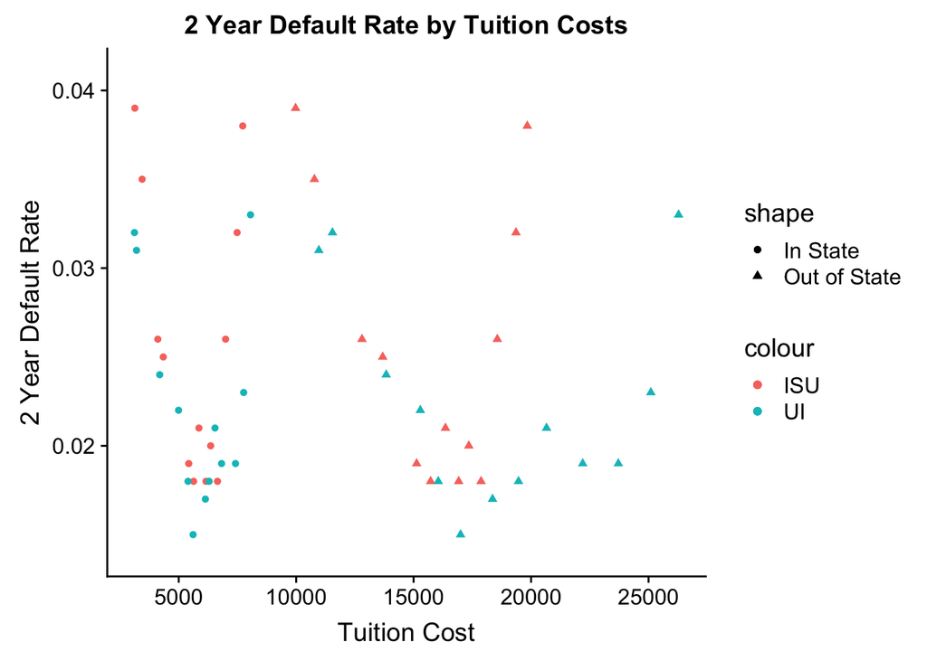

```r
data1 = ISUrepaymentData %>% select(rn,`2_yr_default_rate`)
data2 = UIrepaymentData %>% select(rn,`2_yr_default_rate`)
ISUvsUIdefault = inner_join(data1,data2,by="rn")
ISUvsUIdefault = type.convert(ISUvsUIdefault)
ISUvsUIdefault = ISUvsUIdefault %>% inner_join(ISUvsUIcost,by="rn")
ggplot(ISUvsUIdefault)+
geom_point(aes(x=tuition.out_of_state.x,y=`2_yr_default_rate.x`,color="ISU",shape="Out of State"))+
geom_point(aes(x=tuition.out_of_state.y,y=`2_yr_default_rate.y`,color="UI",shape="Out of State"))+
geom_point(aes(x=tuition.in_state.x,y=`2_yr_default_rate.x`,color="ISU",shape="In State"))+
geom_point(aes(x=tuition.in_state.y,y=`2_yr_default_rate.y`,color="UI",shape="In State")) + scale_x_continuous(breaks = seq(from = 0, to=30000, by = 5000)) + scale_y_continuous(breaks = seq(from = 0.01, to=0.04, by = 0.005)) + ylim(0.014,0.041) + xlab("Tuition Cost") + ylab("2 Year Default Rate") + ggtitle("2 Year Default Rate by Tuition Costs")
```

# Contribution

I chose the data that our group was going to work with. That being said, the data format we had was very tough to parse and was a challenge in itself. I was the one to parse the data into dataframes that we could use to visualize data with. I wrote the first chunk of code in this Rmd file. It took a long time but I eventually got the data into 8 subsections and concatenating each year’s subsection into one large dataframe. I was also the project coordinator and was the owner of the github repo that we used. I also created my five visualizations for the presentation and started the google slides for my group to work within.

### ———SAM———–